# De impact van beheer op de uibreiding van invasieve duizendknoop

Marijke Thoonen

15 januari, 2024

Histogram van de relatieve jaarlijkse uitbreiding in %

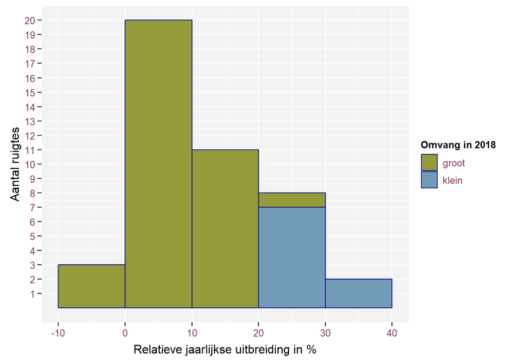

Boxplot van de relatieve jaarlijkse uitbreiding per begrenzingstype

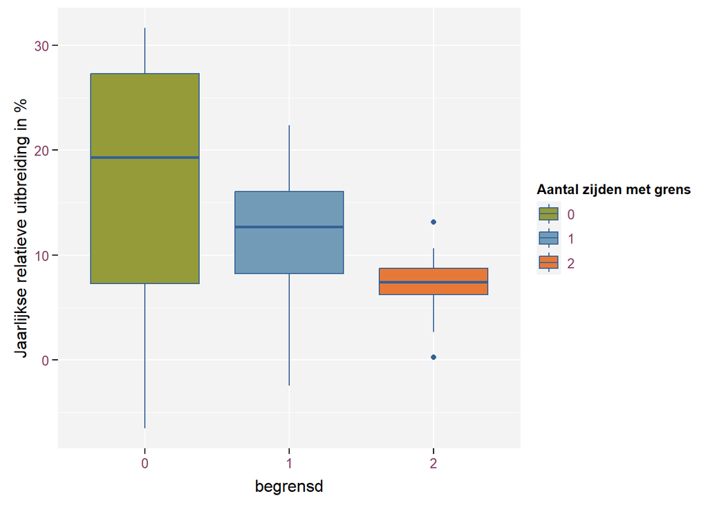

Gemiddelde, mediaan, minimale en maximale relatieve jaarlijkse uitbreiding

```
##   gemiddelde mediaan       min      max variantie
## 1   12.37786 9.18486 -6.483402 31.61954  92.82816
```

Ruigtes met nulbeheer breiden gemiddeld 12% uit per jaar, terwijl ruigtes met maaibeheer gemiddeld 13% uitbreiden per jaar.

```
## # A tibble: 2 × 6
##   beheer     gemiddelde mediaan min   max   var
##   <fct>      <chr>      <chr>   <chr> <chr> <chr>
## 1 nulbeheer  12.2%      9.2%    -2.4% 31.6% 0.7%
## 2 maaibeheer 13.0%      12.6%   -6.5% 31.3% 1.8%
```

```
## "";"x"
## "1";"./sum_stat_beheer.csv"
```

Door duizendknoop laagfrequent te maaien stijgt de jaarlijkse relatieve uitbreiding gemiddeld 6%

```
## [1] 6.12552
```

Tellen van vertegenwoordinging omgevingskenmerken

```
##  groot_of_klein  n percent
##           groot 35     80%
##           klein  9     20%
```

```
##     soort  n percent
##  Bohemica 11     25%
##  Japonica 33     75%
```

```
##  aard_terrein  n percent
##          dijk 34     77%
##         oever  5     11%
##      grasland  1      2%
##        natuur  3      7%
##       wegberm  1      2%
```

```
##  bodem_ondergrond  n percent
##        breuksteen 14     32%
##          zandleem 23     52%
##              klei  4      9%
##              leem  2      5%
##              zand  1      2%
```

```
##  begrensd  n percent
##         0 18     41%
##         1 12     27%
##         2 14     32%
```

We voeren een uitbreiding op onze t-test uit waarbij beheer een factorvariabele is met levels “gemaaid” en “nulbeheer”. We gebruiken een model (generalized least squares) om aparte variantie fit voor gemaaid en nulbeheer uit te voeren. Opmerking: Als je het “weights =” gedeelte weglaat, heb je hetzelfde als de t-test. Het enige verschil is dat je bij gls een F-statistiek in de output van anova(fm1) zal zien en bij de t-test krijg je een t-statistiek. Als je de t-statistiek kwadrateert zou deze gelijk moeten zijn aan de F-statistiek.

|  | numDF | F-value | p-value |
| --- | --- | --- | --- |
| beheer | 2 | 40.03945 | 1.856876e-10 |

```
## Generalized least squares fit by REML
##   Model: rel_uitbr_jaar ~ 0 + beheer
##   Data: df
##         AIC       BIC   logLik
##   -66.11026 -59.15958 37.05513
##
## Variance function:
##  Structure: Different standard deviations per stratum
##  Formula: ~1 | beheer
##  Parameter estimates:
##  nulbeheer maaibeheer
##   1.000000   1.588078
##
## Coefficients:
##                      Value  Std.Error  t-value p-value
## beheernulbeheer  0.1220791 0.01451042 8.413201   0.000
## beheermaaibeheer 0.1295571 0.04249044 3.049087   0.004
##
##  Correlation:
##                  bhrnlb
## beheermaaibeheer 0
##
## Standardized residuals:
##        Min         Q1        Med         Q3        Max
## -1.7301898 -0.6239397 -0.3434900  0.6305726  2.2942599
##
## Residual standard error: 0.08460955
## Degrees of freedom: 44 total; 42 residual
```

```
## Generalized least squares fit by REML
##   Model: rel_uitbr_jaar ~ 0 + beheer
##   Data: df
##         AIC       BIC   logLik
##   -64.58022 -59.36722 35.29011
##
## Coefficients:
##                      Value  Std.Error  t-value p-value
## beheernulbeheer  0.1220791 0.01670994 7.305777   0e+00
## beheermaaibeheer 0.1295571 0.03081160 4.204814   1e-04
##
##  Correlation:
##                  bhrnlb
## beheermaaibeheer 0
##
## Standardized residuals:
##        Min         Q1        Med         Q3        Max
## -1.9950881 -0.5770616 -0.3102635  0.5777516  1.9922680
##
## Residual standard error: 0.09743483
## Degrees of freedom: 44 total; 42 residual
```

|  | call | Model | df | AIC | BIC | logLik | Test | L.Ratio | p-value |
| --- | --- | --- | --- | --- | --- | --- | --- | --- | --- |
| fm1 | gls(model = rel_uitbr_jaar ~ 0 + beheer, data = df, weights = varIdent(form = ~1 \| beheer)) | 1 | 4 | -66.11026 | -59.15958 | 37.05513 |  | NA | NA |
| fm2 | gls(model = rel_uitbr_jaar ~ 0 + beheer, data = df) | 2 | 3 | -64.58022 | -59.36722 | 35.29011 | 1 vs 2 | 3.530036 | 0.06026647 |

Boxplot die het maaibeheer met nulbeheer vergelijkt

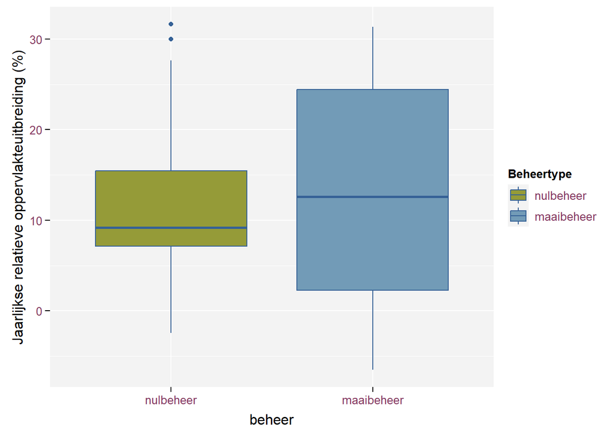

Boxplot die het maaibeheer met nulbeheer vergelijkt voor de onbegrensde haarden

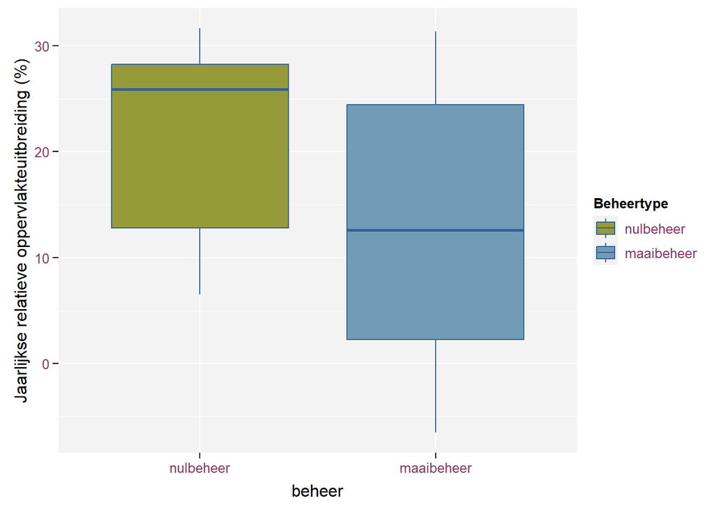

Statistische test voor dataset met enkel onbegrensde haarden

|  | numDF | F-value | p-value |
| --- | --- | --- | --- |
| beheer | 2 | 17.93022 | 8.208611e-05 |

```
## Generalized least squares fit by REML
##   Model: rel_uitbr_jaar ~ 0 + beheer
##   Data: df_O
##         AIC       BIC   logLik
##   -11.74727 -9.429499 8.873633
##
## Coefficients:
##                      Value  Std.Error  t-value p-value
## beheernulbeheer  0.2117620 0.04284357 4.942678  0.0001
## beheermaaibeheer 0.1295571 0.03832045 3.380885  0.0038
##
##  Correlation:
##                  bhrnlb
## beheermaaibeheer 0
##
## Standardized residuals:
##        Min         Q1        Med         Q3        Max
## -1.6041526 -0.8998955  0.3228788  0.7218608  1.5168554
##
## Residual standard error: 0.1211799
## Degrees of freedom: 18 total; 16 residual
```